# Linear regression

Austin Miller

2022-11-04

# Runs Data

```r
data = read.csv("attendance-2016.csv", header = TRUE)
data_runs = data.frame(data$HomeAvgAtt,data$RunsPerGame)

colnames(data_runs) = c("attendance","runs")



knitr::kable(data_runs, align = "c") %>%
  kable_styling("striped",full_width = F, position = "center")%>%
  scroll_box(height = "300px", width="100%", fixed_thead = T)
```

| attendance | runs |
| --- | --- |
| 26819 | 4.59 |
| 36486 | 5.42 |
| 21828 | 4.23 |
| 19650 | 4.83 |
| 31173 | 4.66 |
| 28476 | 4.47 |
| 31576 | 4.17 |
| 37236 | 4.43 |
| 24245 | 4.46 |
| 37819 | 4.20 |
| 18784 | 4.03 |
| 27999 | 4.74 |
| 15878 | 4.15 |
| 33461 | 4.72 |
| 41880 | 4.69 |
| 25138 | 4.64 |
| 24949 | 4.03 |
| 39906 | 4.99 |
| 23383 | 4.42 |
| 32129 | 5.22 |
| 45719 | 4.48 |
| 21405 | 4.07 |
| 28575 | 4.14 |
| 34870 | 4.14 |
| 23643 | 3.77 |
| 28112 | 4.50 |
| 29029 | 4.23 |
| 41546 | 4.41 |
| 42524 | 4.81 |
| 30641 | 4.71 |

# Correlation

Runs per game and attendance have a correlation point estimate of 39.9%.

```r
cor.test(data_runs$attendance, data_runs$runs)
```

```
##
##  Pearson's product-moment correlation
##
## data:  data_runs$attendance and data_runs$runs
## t = 2.304, df = 28, p-value = 0.02886
## alternative hypothesis: true correlation is not equal to 0
## 95 percent confidence interval:
##  0.04548745 0.66398609
## sample estimates:
##       cor
## 0.3992145
```

# Visualize

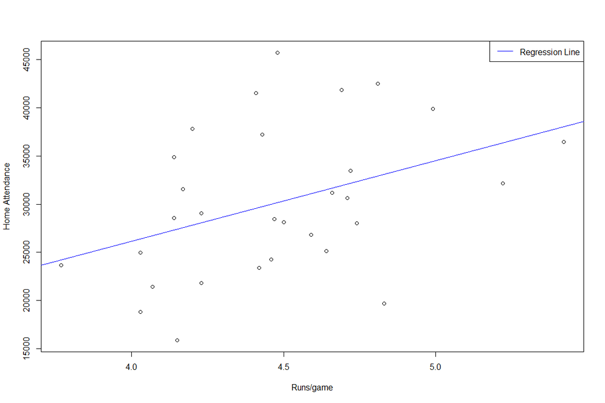

```r
lm_runs <- lm(attendance~runs, data=data_runs)

plot(attendance ~ runs, data_runs, ylab = "Home Attendance", xlab = "Runs/game")
abline(lm_runs, col="blue")
legend("topright", legend = c("Regression Line"),
       lty = c(1), col = c("blue"), cex = 1)
```

# LM Summary

The summary of the linear model agrees that correlation exists as well. The p-value is under the significance level of 0.05 and a positive t-value tells us a positive correlation exists.

```r
run_resid <- data.frame(lm_runs$residuals)
summary(lm_runs)
```

```
##
## Call:
## lm(formula = attendance ~ runs, data = data_runs)
##
## Residuals:
##    Min     1Q Median     3Q    Max
## -13460  -5091  -1460   5091  15542
##
## Coefficients:
##             Estimate Std. Error t value Pr(>|t|)
## (Intercept)    -7372      16344  -0.451   0.6554
## runs            8381       3638   2.304   0.0289 *
## ---
## Signif. codes:  0 '***' 0.001 '**' 0.01 '*' 0.05 '.' 0.1 ' ' 1
##
## Residual standard error: 7224 on 28 degrees of freedom
## Multiple R-squared:  0.1594, Adjusted R-squared:  0.1293
## F-statistic: 5.308 on 1 and 28 DF,  p-value: 0.02886
```

# Assumptions

Both the standardized residual plot and the qq plot points to residuals being normally distributed without any major outliers. The residuals vs. fitted plot is not a perfectly flat line but there doesn’t appear to be a pattern or funnel effect. The scale location plot also doesn’t have a perfectly straight line, but the data points seem to be equally scattered, which points to homoscedasticity. It doesn’t appear that transforming the data is necessary but because of the small size of the data set, running simulations and removing the doubts of assumption would be beneficial.

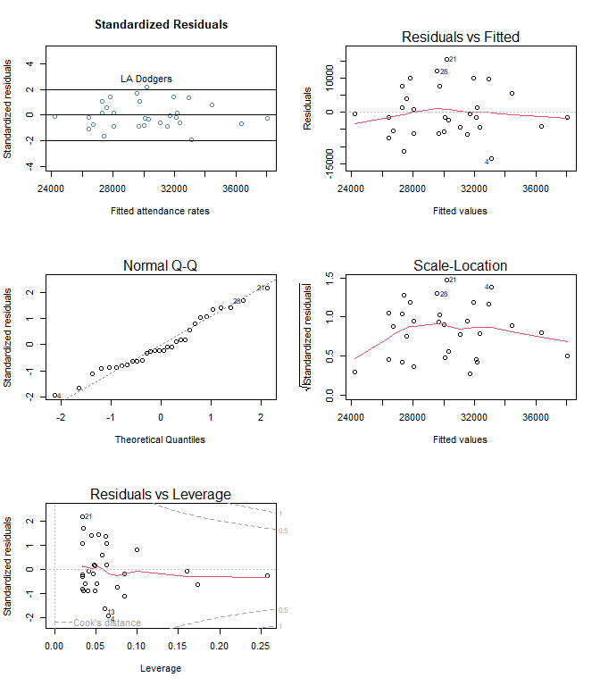

```r
par(mfrow=c(3,2))


plot(fitted(lm_runs), rstandard(lm_runs), pch=1, col="steelblue",
    xlab = "Fitted attendance rates", ylab = "Standardized residuals",
    ylim=c(-4,5), main = "Standardized Residuals")
text(c(lm_runs$fitted.values[abs(rstandard(lm_runs))>2]),
    rstandard(lm_runs)[abs(rstandard(lm_runs))>2],
    data$TEAM[abs(rstandard(lm_runs))>2], pos = 3)
abline(h=c(-2,0,2))

plot(lm_runs)
```

# Theoretical Point Estimate and CI

The linear model estimated the slope of the line correlating attendance to runs per game to be 8,381.345. That means for every run scored, attendance is predicted to rise by 8,381.345. The 95% CI produced by the lm is 929.7952 to 15,832.89.

```r
lm_runs$coefficients[2]
```

```
##     runs
## 8381.345
```

```r
confint(lm_runs,'runs',level=0.95)
```

```
##         2.5 %   97.5 %
## runs 929.7952 15832.89
```

# Permutation

```r
set.seed(5555)

perm_run <- replicate(10000, summary(lm(attendance~sample(runs), data=data_runs))$fstatistic[1])
```

# F-stat distribution

Plotting the F stat distribution under the Null hypothesis (no correlation exists), shows us that our observed F-statistic, 5.308, is outside of the permutation distributions 95% CI. This tells us that the permutation distribution agrees that Runs per game and attendance are correlated.

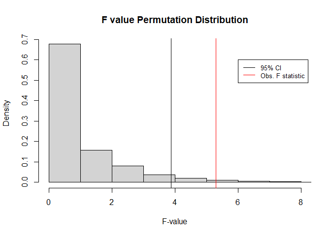

```r
hist(perm_run, freq = FALSE, main = "F value Permutation Distribution", xlab = "F-value", xlim=c(0,8))

abline(v=quantile(perm_run, probs=.95))

abline(v=summary(lm_runs)$fstatistic[1], col="red")

legend(6,.6,  c("95% CI", "Obs. F statistic"), lty=c(1,1), col=c("black", "red") , cex = .8)
```

# Bootstrap

```r
set.seed(5555)


slope_function_runs <- function(dat, inds) {
  d <- dat[inds,]
  return(with(d,lm(attendance~runs,d)$coefficients[2]))
}

boot.data_runs <- boot(data_runs, slope_function_runs, R = 10000)
```

# Bootstrap Slope Estimate

The Bootstrap slope estimate is 8,456.051. This means for every 1 run scored, attendance increases by 8,456.051.

```r
mean(boot.data_runs$t)
```

```
## [1] 8456.051
```

# Bootstrap CI

```r
bootCI_runs <- boot.ci(boot.data_runs,type=c("norm", "perc"), conf = .95)
bootCI_runs
```

```
## BOOTSTRAP CONFIDENCE INTERVAL CALCULATIONS
## Based on 10000 bootstrap replicates
##
## CALL :
## boot.ci(boot.out = boot.data_runs, conf = 0.95, type = c("norm",
##     "perc"))
##
## Intervals :
## Level      Normal             Percentile
## 95%   ( 2160, 14453 )   ( 2361, 15056 )
## Calculations and Intervals on Original Scale
```

# Win Data

```r
data_won = data.frame(data$HomeAvgAtt,data$Won)

colnames(data_won) = c("attendance","won")



knitr::kable(data_won, align = "c") %>%
  kable_styling("striped",full_width = F, position = "center")%>%
  scroll_box(height = "300px", width="100%", fixed_thead = T)
```

| attendance | won |
| --- | --- |
| 26819 | 89 |
| 36486 | 93 |
| 21828 | 78 |
| 19650 | 94 |
| 31173 | 86 |
| 28476 | 84 |
| 31576 | 81 |
| 37236 | 74 |
| 24245 | 59 |
| 37819 | 84 |
| 18784 | 69 |
| 27999 | 87 |
| 15878 | 68 |
| 33461 | 95 |
| 41880 | 89 |
| 25138 | 69 |
| 24949 | 68 |
| 39906 | 103 |
| 23383 | 68 |
| 32129 | 75 |
| 45719 | 91 |
| 21405 | 79 |
| 28575 | 73 |
| 34870 | 87 |
| 23643 | 71 |
| 28112 | 78 |
| 29029 | 68 |
| 41546 | 86 |
| 42524 | 86 |
| 30641 | 95 |

# Correlation

The Pearson correlation estimates that Attendance and Wins have a 55.7% correlation.

```r
cor.test(data_won$attendance, data_won$won)
```

```
##
##  Pearson's product-moment correlation
##
## data:  data_won$attendance and data_won$won
## t = 3.5504, df = 28, p-value = 0.001382
## alternative hypothesis: true correlation is not equal to 0
## 95 percent confidence interval:
##  0.2463489 0.7640661
## sample estimates:
##       cor
## 0.5571683
```

# Visualize

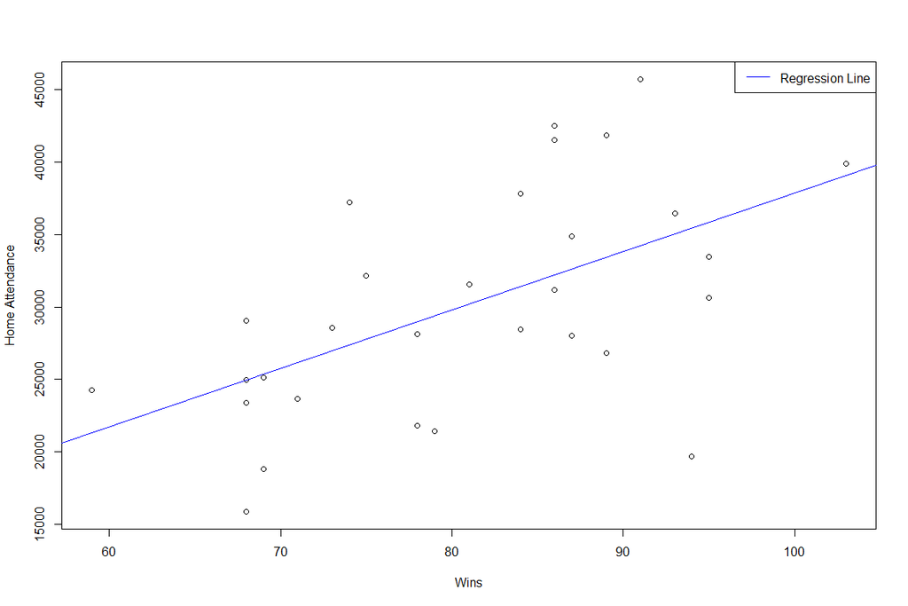

```r
lm_won <- lm(attendance~won, data=data_won)

plot(attendance ~ won, data_won, ylab = "Home Attendance", xlab = "Wins")
abline(lm_won, col="blue")
legend("topright", legend = c("Regression Line"),
       lty = c(1), col = c("blue"), cex = 1)
```

# LM Summary

The summary of the linear model agrees with the pearson correlation that wins and attendance are correlated.

```r
win_resid <- data.frame(lm_won$residuals)
summary(lm_won)
```

```
##
## Call:
## lm(formula = attendance ~ won, data = data_won)
##
## Residuals:
##      Min       1Q   Median       3Q      Max
## -15809.4  -4207.6   -105.4   3796.0  11472.6
##
## Coefficients:
##             Estimate Std. Error t value Pr(>|t|)
## (Intercept)  -2547.8     9290.3  -0.274  0.78591
## won            404.3      113.9   3.550  0.00138 **
## ---
## Signif. codes:  0 '***' 0.001 '**' 0.01 '*' 0.05 '.' 0.1 ' ' 1
##
## Residual standard error: 6543 on 28 degrees of freedom
## Multiple R-squared:  0.3104, Adjusted R-squared:  0.2858
## F-statistic: 12.61 on 1 and 28 DF,  p-value: 0.001382
```

# Assumptions

The plots for the residuals of attendance~wins are not perfect, but they do not show significant deviations from the assumptions of the linear model. Therefore, no transformation will be necessary.

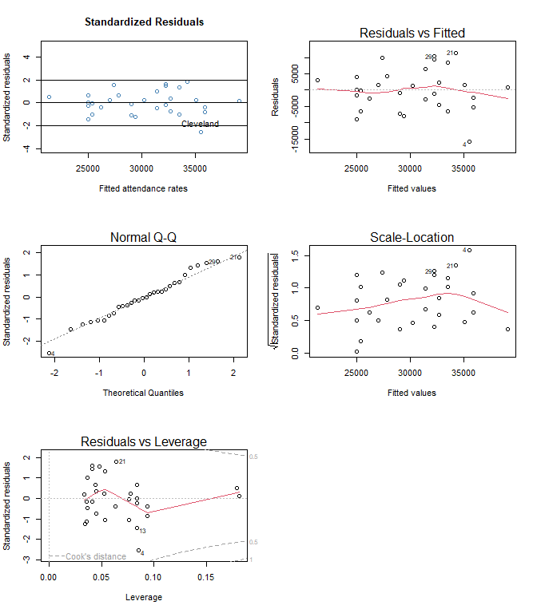

```r
par(mfrow=c(3,2))


plot(fitted(lm_won), rstandard(lm_won), pch=1, col="steelblue",
    xlab = "Fitted attendance rates", ylab = "Standardized residuals",
    ylim=c(-4,5), main = "Standardized Residuals")
text(c(lm_won$fitted.values[abs(rstandard(lm_won))>2]),
    rstandard(lm_won)[abs(rstandard(lm_won))>2],
    data$TEAM[abs(rstandard(lm_won))>2], pos = 3)
abline(h=c(-2,0,2))

plot(lm_won)
```

# Theoretical Point Estimate and CI

For every win a team gets, the attendance is predicted to increase by 404.3 with a 95% CI of 171.05 to 637.61.

```r
lm_won$coefficients[2]
```

```
##      won
## 404.3321
```

```r
confint(lm_won,'won',level=0.95)
```

```
##        2.5 %   97.5 %
## won 171.0528 637.6114
```

# Permutation

```r
set.seed(5555)

perm_won <- replicate(10000, summary(lm(attendance~sample(won), data=data_won))$fstatistic[1])
```

# F-stat distribution

The permutation distribution agrees that a relationship exists between wins and attendance.

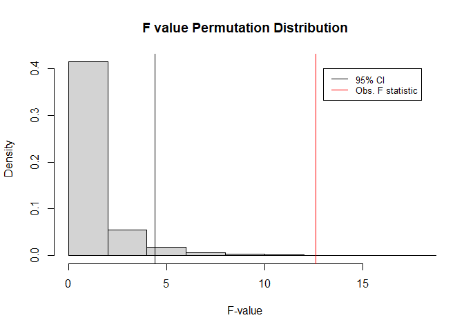

```r
hist(perm_won, freq = FALSE, main = "F value Permutation Distribution", xlab = "F-value", xlim=c(0,18))

abline(v=quantile(perm_won, probs=.95))

abline(v=summary(lm_won)$fstatistic[1], col="red")

legend(13,.4,  c("95% CI", "Obs. F statistic"), lty=c(1,1), col=c("black", "red") , cex = .8)
```

# Bootstrap

```r
set.seed(5555)


slope_function_won <- function(dat, inds) {
  d <- dat[inds,]
  return(with(d,lm(attendance~won,d)$coefficients[2]))
}

boot.data_won <- boot(data_won, slope_function_won, R = 10000)
```

# Bootstrap Estimate

The bootstrap estimate predicts that for every win, attendance will rise by 406.68.

```r
mean(boot.data_won$t)
```

```
## [1] 406.6825
```

# Bootstrap CI

```r
bootCI_won <- boot.ci(boot.data_won,type=c("norm", "perc"), conf = .95)
bootCI_won
```

```
## BOOTSTRAP CONFIDENCE INTERVAL CALCULATIONS
## Based on 10000 bootstrap replicates
##
## CALL :
## boot.ci(boot.out = boot.data_won, conf = 0.95, type = c("norm",
##     "perc"))
##
## Intervals :
## Level      Normal             Percentile
## 95%   (185.2, 618.7 )   (190.9, 632.3 )
## Calculations and Intervals on Original Scale
```